# Intro to Data Science - HW 5

##### Copyright Jeffrey Stanton, Jeffrey Saltz, and Jasmina Tacheva

```r
# Enter your name here: Patrick Walsh
```

### Attribution statement: (choose only one and delete the rest)

```r
# 1. I did this homework by myself, with help from the book and the professor.
```

**This module:** **Data visualization** is important because many people can make sense of data more easily when it is presented in graphic form. As a data scientist, you will have to present complex data to decision makers in a form that makes the data interpretable for them. From your experience with Excel and other tools, you know that there are a variety of **common data visualizations** (e.g., pie charts). How many of them can you name?

The most powerful tool for data visualization in R is called **ggplot**. Written by computer/data scientist **Hadley Wickham**, this **“graphics grammar”** tool builds visualizations in layers. This method provides immense flexibility, but takes a bit of practice to master.

## Step 1: Make a copy of the data

1. Read the **who** dataset from this URL: https://intro-datascience.s3.us-east-2.amazonaws.com/who.csv  
   into a new dataframe called **tb**.

Your new dataframe, tb, contains a so-called **multivariate time series**: a sequence of measurements on 23 Tuberculosis-related (TB) variables captured repeatedly over time (1980-2013). Familiarize yourself with the nature of the 23 variables by consulting the dataset’s codebook which can be found here: https://intro-datascience.s3.us-east-2.amazonaws.com/TB_data_dictionary_2021-02-06.csv.

```r
library(tidyverse)
tb <- read.csv("https://intro-datascience.s3.us-east-2.amazonaws.com/who.csv")
glimpse(tb)
```

```
## Rows: 5,769
## Columns: 23
## $ iso2         <chr> "AD", "AD", "AD", "AD", "AD", "AD", "AD", "AD", "AD", "AD…
## $ year         <int> 1989, 1990, 1991, 1992, 1993, 1994, 1996, 1997, 1998, 199…
## $ new_sp       <int> NA, NA, NA, NA, 15, 24, 8, 17, 1, 4, 1, 3, 2, 7, 3, 5, 8,…
## $ new_sp_m04   <int> NA, NA, NA, NA, NA, NA, NA, NA, NA, NA, NA, NA, NA, NA, N…
## $ new_sp_m514  <int> NA, NA, NA, NA, NA, NA, NA, NA, NA, NA, NA, NA, NA, NA, N…
## $ new_sp_m014  <int> NA, NA, NA, NA, NA, NA, 0, 0, 0, 0, 0, 0, 0, 0, 0, 0, 0, …
## $ new_sp_m1524 <int> NA, NA, NA, NA, NA, NA, 0, 0, 0, 0, 0, NA, 0, 0, 0, 0, 1,…
## $ new_sp_m2534 <int> NA, NA, NA, NA, NA, NA, 0, 1, 0, 0, 1, NA, 0, 0, 0, 1, 1,…
## $ new_sp_m3544 <int> NA, NA, NA, NA, NA, NA, 4, 2, 1, 1, 0, 2, 1, 1, 1, 1, 2, …
## $ new_sp_m4554 <int> NA, NA, NA, NA, NA, NA, 1, 2, 0, 1, 0, 1, 0, 2, 1, 0, 0, …
## $ new_sp_m5564 <int> NA, NA, NA, NA, NA, NA, 0, 1, 0, 0, 0, NA, 0, 0, 0, 0, 1,…
## $ new_sp_m65   <int> NA, NA, NA, NA, NA, NA, 0, 6, 0, 0, 0, NA, 0, 0, 0, 0, 1,…
## $ new_sp_mu    <int> NA, NA, NA, NA, NA, NA, NA, NA, NA, NA, NA, NA, NA, NA, N…
## $ new_sp_f04   <int> NA, NA, NA, NA, NA, NA, NA, NA, NA, NA, NA, NA, NA, NA, N…
## $ new_sp_f514  <int> NA, NA, NA, NA, NA, NA, NA, NA, NA, NA, NA, NA, NA, NA, N…
## $ new_sp_f014  <int> NA, NA, NA, NA, NA, NA, 0, 0, NA, 0, NA, NA, 0, 0, 0, 0, …
## $ new_sp_f1524 <int> NA, NA, NA, NA, NA, NA, 1, 1, NA, 0, NA, NA, 1, 1, 0, 1, …
## $ new_sp_f2534 <int> NA, NA, NA, NA, NA, NA, 1, 2, NA, 0, NA, NA, 0, 1, 1, 1, …
## $ new_sp_f3544 <int> NA, NA, NA, NA, NA, NA, 0, 3, NA, 1, NA, NA, 0, 1, 0, 1, …
## $ new_sp_f4554 <int> NA, NA, NA, NA, NA, NA, 0, 0, NA, 0, NA, NA, 0, 0, 0, 0, …
## $ new_sp_f5564 <int> NA, NA, NA, NA, NA, NA, 1, 0, NA, 0, NA, NA, 0, 0, 0, 0, …
## $ new_sp_f65   <int> NA, NA, NA, NA, NA, NA, 0, 1, NA, 0, NA, NA, 0, 0, 0, 0, …
## $ new_sp_fu    <int> NA, NA, NA, NA, NA, NA, NA, NA, NA, NA, NA, NA, NA, NA, N…
```

2. How often were these measurements taken (in other words, at what frequency were the variables measured)? Put your answer in a comment.

```r
# Each variable was taken once a year for each iso2
```

## Step 2: Clean-up the NAs and create a subset

1. Let’s clean up the iso2 attribute in **tb**

Hint: use *is.na()* – well use *! is.na()*

```r
tb_subset <- subset(tb, !is.na(iso2))
sum(is.na(tb_subset$iso2))  # verify that there are no NA values left in iso2 column
```

```
## [1] 0
```

B. Create a subset of **tb** containing **only the records for Canada (“CA” in the iso2 variable)**. Save it in a new dataframe called **tbCan**. Make sure this new df has **29 observations and 23 variables**.

```r
tbCan <- subset(tb_subset, iso2=="CA")
glimpse(tbCan)
```

```
## Rows: 29
## Columns: 23
## $ iso2         <chr> "CA", "CA", "CA", "CA", "CA", "CA", "CA", "CA", "CA", "CA…
## $ year         <int> 1980, 1981, 1982, 1983, 1984, 1985, 1986, 1987, 1988, 198…
## $ new_sp       <int> 951, 803, 812, 771, 811, 791, 752, 668, 682, 652, 549, 54…
## $ new_sp_m04   <int> NA, NA, NA, NA, NA, NA, NA, NA, NA, NA, NA, NA, NA, NA, N…
## $ new_sp_m514  <int> NA, NA, NA, NA, NA, NA, NA, NA, NA, NA, NA, NA, NA, NA, N…
## $ new_sp_m014  <int> 12, 8, 6, 9, 3, 11, 9, 9, 4, 10, 3, 7, 6, 8, 2, 1, 3, 0, …
## $ new_sp_m1524 <int> 54, 49, 52, 47, 44, 42, 58, 40, 43, 45, 35, 37, 42, 33, 4…
## $ new_sp_m2534 <int> 75, 61, 66, 63, 75, 70, 73, 71, 73, 56, 70, 79, 47, 47, 5…
## $ new_sp_m3544 <int> 83, 64, 69, 62, 58, 59, 62, 60, 62, 60, 55, 53, 58, 53, 4…
## $ new_sp_m4554 <int> 100, 87, 90, 90, 68, 77, 59, 49, 52, 54, 40, 37, 41, 43, …
## $ new_sp_m5564 <int> 108, 103, 91, 92, 83, 81, 73, 64, 68, 62, 42, 36, 51, 33,…
## $ new_sp_m65   <int> 186, 141, 150, 123, 169, 168, 147, 129, 131, 122, 100, 11…
## $ new_sp_mu    <int> NA, NA, NA, NA, NA, NA, NA, NA, NA, NA, NA, NA, NA, NA, N…
## $ new_sp_f04   <int> NA, NA, NA, NA, NA, NA, NA, NA, NA, NA, NA, NA, NA, NA, N…
## $ new_sp_f514  <int> NA, NA, NA, NA, NA, NA, NA, NA, NA, NA, NA, NA, NA, NA, N…
## $ new_sp_f014  <int> 18, 6, 7, 11, 9, 5, 10, 8, 6, 6, 1, 4, 2, 6, 3, 7, 2, 1, …
## $ new_sp_f1524 <int> 62, 46, 51, 50, 51, 30, 33, 39, 38, 37, 30, 23, 27, 22, 3…
## $ new_sp_f2534 <int> 51, 57, 57, 50, 59, 56, 54, 48, 56, 51, 38, 37, 28, 50, 3…
## $ new_sp_f3544 <int> 34, 26, 30, 29, 28, 19, 33, 29, 27, 23, 26, 31, 21, 22, 1…
## $ new_sp_f4554 <int> 31, 28, 25, 24, 28, 28, 20, 17, 16, 24, 17, 9, 11, 21, 11…
## $ new_sp_f5564 <int> 33, 35, 38, 35, 36, 48, 26, 26, 26, 21, 20, 20, 15, 21, 1…
## $ new_sp_f65   <int> 104, 92, 80, 86, 100, 97, 95, 79, 80, 81, 72, 60, 78, 55,…
## $ new_sp_fu    <int> NA, NA, NA, NA, NA, NA, NA, NA, NA, NA, NA, NA, NA, NA, N…
```

C. A simple method for dealing with small amounts of **missing data** in a numeric variable is to **substitute the mean of the variable in place of each missing datum**.  
This expression locates (and reports to the console) all the missing data elements in the variable measuring the **number of positive pulmonary smear tests for male children 0-4 years old** (there are 26 data points missing)

```r
tbCan$new_sp_m04[is.na(tbCan$new_sp_m04)]
```

```
##  [1] NA NA NA NA NA NA NA NA NA NA NA NA NA NA NA NA NA NA NA NA NA NA NA NA NA
## [26] NA
```

[output not shown]

4. Write a comment describing how that statement works.

```r
# The first part of the code reads the new_sp_m04 column from the tbCan dataframe: tbCan$new_sp_m04.
# Next, square brackets are used to index certain elements from that dataframe and column.
# Within the square brackets, we use the is.na() function to select only the elements of that dataframe
# and column that are NA.
```

5. Write 4 more statements to check if there is missing data for the number of positive pulmonary smear tests for: **male and female** children 0-14 years old (**new_sp_m014** and **new_sp_f014**), and **male and female citizens 65 years of age and older**, respectively. What does empty output suggest about the number of missing observations?

```r
tbCan$new_sp_m014[is.na(tbCan$new_sp_m014)]
```

```
## integer(0)
```

```r
tbCan$new_sp_f014[is.na(tbCan$new_sp_f014)]
```

```
## integer(0)
```

```r
tbCan$new_sp_m65[is.na(tbCan$new_sp_m65)]
```

```
## integer(0)
```

```r
tbCan$new_sp_f65[is.na(tbCan$new_sp_f65)]
```

```
## integer(0)
```

```r
# Empty output means that there are no NA values in that column.
```

There is an R package called **imputeTS** specifically designed to repair missing values in time series data. We will use this instead of mean substitution.  
The **na_interpolation()** function in this package takes advantage of a unique characteristic of time series data: **neighboring points in time can be used to “guess” about a missing value in between**.

6. Install the **imputeTS** package (if needed) and use **na_interpolation( )** on the variable from part C. Don’t forget that you need to save the results back to the **tbCan** dataframe. Also update any attribute discussed in part E (if needed).

```r
#install.packages("imputeTS")
library(imputeTS)
tbCan$new_sp_m04 <- na_interpolation(tbCan$new_sp_m04)
```

7. Rerun the code from C and E above to check that all missing data have been fixed.

```r
# From Step C:
tbCan$new_sp_m04[is.na(tbCan$new_sp_m04)]
```

```
## numeric(0)
```

```r
# From Step E:
tbCan$new_sp_m014[is.na(tbCan$new_sp_m014)]
```

```
## integer(0)
```

```r
tbCan$new_sp_f014[is.na(tbCan$new_sp_f014)]
```

```
## integer(0)
```

```r
tbCan$new_sp_m65[is.na(tbCan$new_sp_m65)]
```

```
## integer(0)
```

```r
tbCan$new_sp_f65[is.na(tbCan$new_sp_f65)]
```

```
## integer(0)
```

## Step 3: Use ggplot to explore the distribution of each variable

**Don’t forget to install and library the ggplot2 package.** Then:  
H. Create a histogram for **new_sp_m014**. Be sure to add a title and briefly describe what the histogram means in a comment.

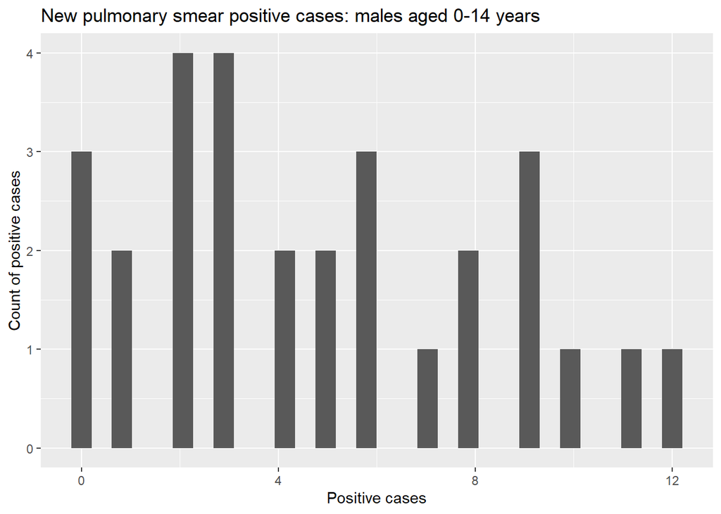

```r
install.packages("ggplot2")
library(ggplot2)

ggplot(tbCan, aes(x=new_sp_m014))+
  ggtitle("New pulmonary smear positive cases: males aged 0-14 years")+
  labs(x="Positive cases", y="Count of positive cases")+
  geom_histogram()
```

```r
# Histogram shows the positive cases along the X  axis and number of positive cases along the Y axis.
```

1. Create histograms (using ggplot) of each of the other three variables from E with ggplot( ).  
   Which parameter do you need to adjust to make the other histograms look right?

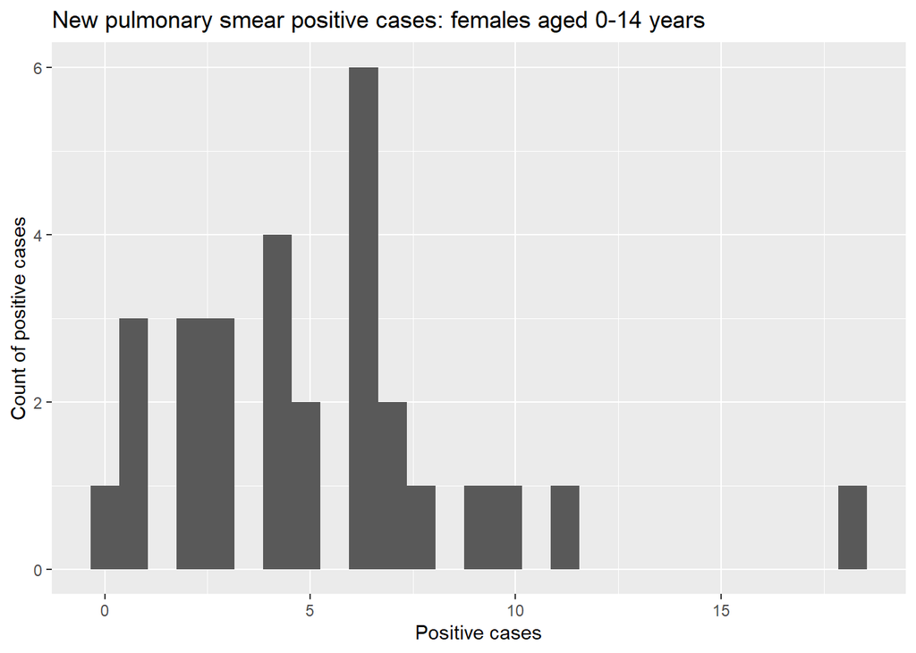

```r
# You need to adjust the binwidth parameter so that the columns shown in the histograms fit the data.
# You should also adjust the title to match the data being presented.

ggplot(tbCan, aes(x=new_sp_f014))+
  ggtitle("New pulmonary smear positive cases: females aged 0-14 years")+
  labs(x="Positive cases", y="Count of positive cases")+
  geom_histogram(binwidth = 0.7)
```

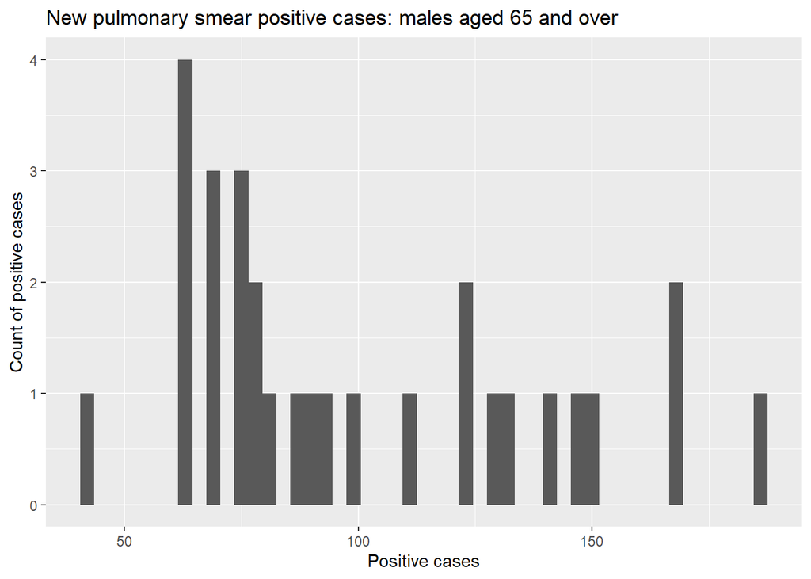

```r
ggplot(tbCan, aes(x=new_sp_m65))+
  ggtitle("New pulmonary smear positive cases: males aged 65 and over")+
  labs(x="Positive cases", y="Count of positive cases")+
  geom_histogram(binwidth = 3)
```

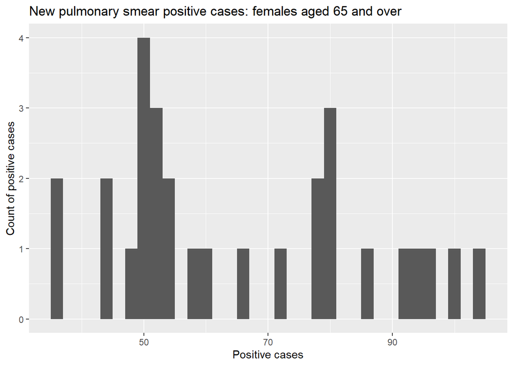

```r
ggplot(tbCan, aes(x=new_sp_f65))+
  ggtitle("New pulmonary smear positive cases: females aged 65 and over")+
  labs(x="Positive cases", y="Count of positive cases")+
  geom_histogram(binwidth = 2)
```

## Step 4: Explore how the data changes over time

10. These data were collected in a period of several decades (1980-2013). You can thus observe changes over time with the help of a line chart. Create a **line chart**, with **year** on the X-axis and **new_sp_m014** on the Y-axis.

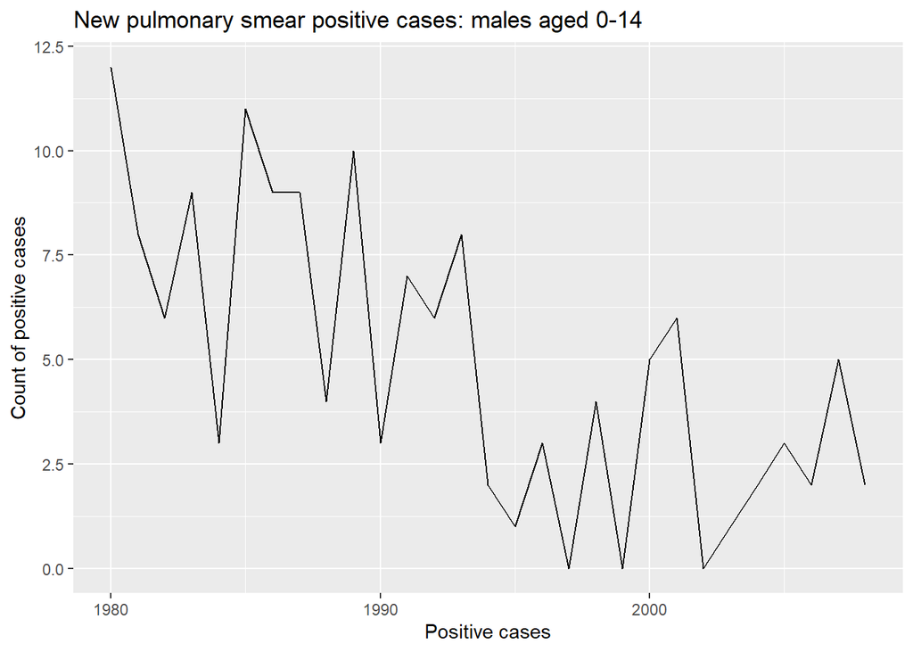

```r
ggplot(tbCan, aes(x=year, y=new_sp_m014))+
  ggtitle("New pulmonary smear positive cases: males aged 0-14")+
  labs(x="Positive cases", y="Count of positive cases")+
  geom_line()
```

11. Next, create similar graphs for each of the other three variables. Change the **color** of the line plots (any color you want).

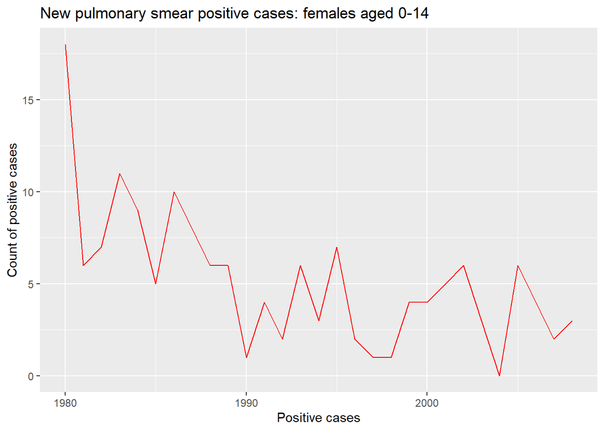

```r
ggplot(tbCan, aes(x=year, y=new_sp_f014))+
  ggtitle("New pulmonary smear positive cases: females aged 0-14")+
  labs(x="Positive cases", y="Count of positive cases")+
  geom_line(color="red")
```

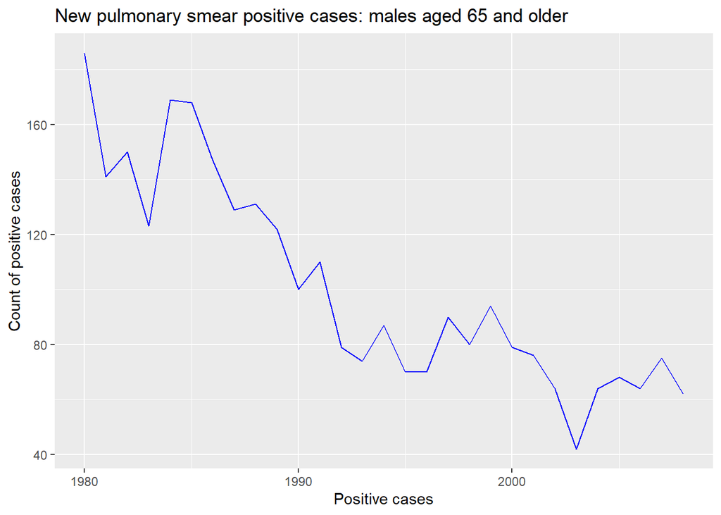

```r
ggplot(tbCan, aes(x=year, y=new_sp_m65))+
  ggtitle("New pulmonary smear positive cases: males aged 65 and older")+
  labs(x="Positive cases", y="Count of positive cases")+
  geom_line(color="blue")
```

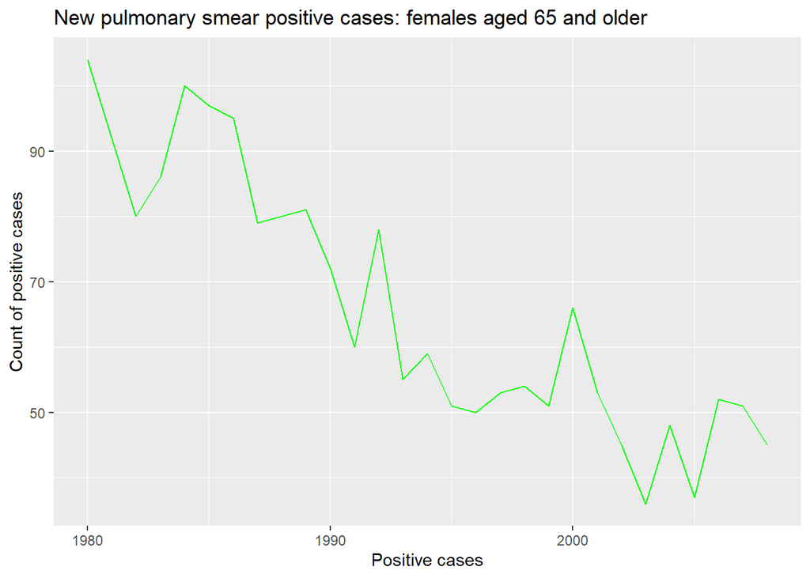

```r
ggplot(tbCan, aes(x=year, y=new_sp_f65))+
  ggtitle("New pulmonary smear positive cases: females aged 65 and older")+
  labs(x="Positive cases", y="Count of positive cases")+
  geom_line(color="green")
```

12. Using vector math, create a new variable by combining the numbers from **new_sp_m014** and **new_sp_f014**. Save the resulting vector as a new variable in the **tbCan** df called **new_sp_combined014**. This new variable represents the number of positive pulmonary smear tests for male AND female children between the ages of 0 and 14 years of age. Do the same for SP **tests among citizens 65 years of age and older** and save the resulting vector in the tbCan variable called **new_sp_combined65**.

```r
# Create new vectors that combine the values of two other vectors
new_sp_combined014 <- c(tbCan$new_sp_m014 + tbCan$new_sp_f014)
new_sp_combined65 <- c(tbCan$new_sp_m65 + tbCan$new_sp_f65)

# Add these new vectors to the dataframe
tbCan <- cbind(tbCan, new_sp_combined014, new_sp_combined65)
glimpse(tbCan)
```

```
## Rows: 29
## Columns: 25
## $ iso2               <chr> "CA", "CA", "CA", "CA", "CA", "CA", "CA", "CA", "CA…
## $ year               <int> 1980, 1981, 1982, 1983, 1984, 1985, 1986, 1987, 198…
## $ new_sp             <int> 951, 803, 812, 771, 811, 791, 752, 668, 682, 652, 5…
## $ new_sp_m04         <dbl> 1, 1, 1, 1, 1, 1, 1, 1, 1, 1, 1, 1, 1, 1, 1, 1, 1, …
## $ new_sp_m514        <int> NA, NA, NA, NA, NA, NA, NA, NA, NA, NA, NA, NA, NA,…
## $ new_sp_m014        <int> 12, 8, 6, 9, 3, 11, 9, 9, 4, 10, 3, 7, 6, 8, 2, 1, …
## $ new_sp_m1524       <int> 54, 49, 52, 47, 44, 42, 58, 40, 43, 45, 35, 37, 42,…
## $ new_sp_m2534       <int> 75, 61, 66, 63, 75, 70, 73, 71, 73, 56, 70, 79, 47,…
## $ new_sp_m3544       <int> 83, 64, 69, 62, 58, 59, 62, 60, 62, 60, 55, 53, 58,…
## $ new_sp_m4554       <int> 100, 87, 90, 90, 68, 77, 59, 49, 52, 54, 40, 37, 41…
## $ new_sp_m5564       <int> 108, 103, 91, 92, 83, 81, 73, 64, 68, 62, 42, 36, 5…
## $ new_sp_m65         <int> 186, 141, 150, 123, 169, 168, 147, 129, 131, 122, 1…
## $ new_sp_mu          <int> NA, NA, NA, NA, NA, NA, NA, NA, NA, NA, NA, NA, NA,…
## $ new_sp_f04         <int> NA, NA, NA, NA, NA, NA, NA, NA, NA, NA, NA, NA, NA,…
## $ new_sp_f514        <int> NA, NA, NA, NA, NA, NA, NA, NA, NA, NA, NA, NA, NA,…
## $ new_sp_f014        <int> 18, 6, 7, 11, 9, 5, 10, 8, 6, 6, 1, 4, 2, 6, 3, 7, …
## $ new_sp_f1524       <int> 62, 46, 51, 50, 51, 30, 33, 39, 38, 37, 30, 23, 27,…
## $ new_sp_f2534       <int> 51, 57, 57, 50, 59, 56, 54, 48, 56, 51, 38, 37, 28,…
## $ new_sp_f3544       <int> 34, 26, 30, 29, 28, 19, 33, 29, 27, 23, 26, 31, 21,…
## $ new_sp_f4554       <int> 31, 28, 25, 24, 28, 28, 20, 17, 16, 24, 17, 9, 11, …
## $ new_sp_f5564       <int> 33, 35, 38, 35, 36, 48, 26, 26, 26, 21, 20, 20, 15,…
## $ new_sp_f65         <int> 104, 92, 80, 86, 100, 97, 95, 79, 80, 81, 72, 60, 7…
## $ new_sp_fu          <int> NA, NA, NA, NA, NA, NA, NA, NA, NA, NA, NA, NA, NA,…
## $ new_sp_combined014 <int> 30, 14, 13, 20, 12, 16, 19, 17, 10, 16, 4, 11, 8, 1…
## $ new_sp_combined65  <int> 290, 233, 230, 209, 269, 265, 242, 208, 211, 203, 1…
```

13. Finally, create a **scatter plot**, showing **new_sp_combined014** on the x axis, **new_sp_combined65** on the y axis, and having the **color and size** of the point represent **year**.

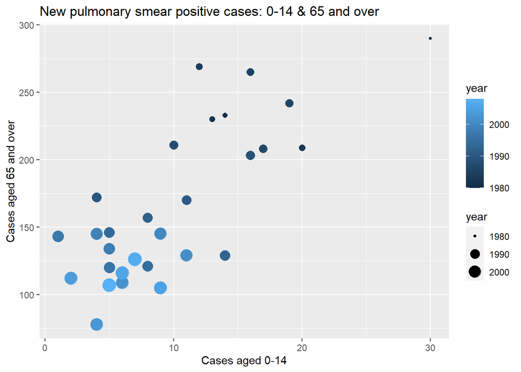

```r
ggplot(tbCan, aes(x=new_sp_combined014, y=new_sp_combined65))+
  ggtitle("New pulmonary smear positive cases: 0-14 & 65 and over")+
  labs(x="Cases aged 0-14", y="Cases aged 65 and over")+
  geom_point(aes(color=year, size=year))
```

14. Interpret this visualization – what insight does it provide?

```r
# It shows that the number of positive TB cases have been in decline from 1980 to 2000.
# The scatter plot uses both color and size to show that the concentration of data
# increases as the size of the points get larger (towards 2000) and turn from black to blue (towards 2000).
```